# Using accelerometer data to predict proficiency in weight lifting

Tomás E. Tecce

# Summary

In this project I use accelerometer data collected from several users doing barbell lifts in different ways to build a predictive model which identifies how the exercise is being done. The original data includes 159 variables. By eliminating columns which mostly consist of empty values, and then using principal component analysis, I obtain 25 features which are then used to build a random forest model. The model obtained, evaluated on a sample separated for calibration from the training set, has an out of sample error of at least 5.53 per cent.

# Source data

Devices such as Jawbone Up, Nike FuelBand, and Fitbit allow users to easily collect large amounts of data about their personal fitness activities. The data can be used not only to quantify how much of a particular activity the users do, but also to determine how well the exercise is done.

The data set for this project comes from http://groupware.les.inf.puc-rio.br/har. It consists of data from accelerometers on the belt, forearm, arm, and dumbell of 6 participants, who were asked to perform barbell lifts correctly and incorrectly in 5 different ways. First, I downloaded the training data set and load it into R as a data frame.

```r
if (!file.exists("data")) { dir.create("data") }
if (!file.exists("data/pml-training.csv")) {
  fileUrl <- "https://d396qusza40orc.cloudfront.net/predmachlearn/pml-training.csv"
  download.file(fileUrl, destfile="data/pml-training.csv", method="curl")
}

dftrain <- read.table("data/pml-training.csv", sep=",",
                      stringsAsFactors=FALSE, header=TRUE,
                      na.strings=c("","NA"))
```

# Feature selection

The training data set consists of 19622 observations of 160 variables. I start by checking for missing data.

Counting the number of NA values in each column I find that the data has either columns with no missing data, or mostly empty columns (all with the same value of 97.9308939 per cent of NAs). I discard the latter columns from the training set, and also columns 1 through 7 which only contain data labels and time stamps.

```r
features.list <- rownames(na_check)[na_check==0][-(1:7)]
dftrain <- dftrain[,features.list]
```

I’m left with 52 features and one outcome variable (`classe`). All the features are numeric, and the outcome is of class character with five possible values (“A”, “B”, “C”, “D” and “E”). At this point I split the original training data into training and calibration datasets.

```r
library(caret)
set.seed(59433)
trainset <- createDataPartition(y=dftrain$classe, p=0.6, list=FALSE)
dftrain1 <- dftrain[trainset,]
dfcal1   <- dftrain[-trainset,]
```

The next step is to check for correlation among these features. The motions performed during exercising are not completely independent of each other, and in principle it is possible for the measurements in the different accelerometers to be correlated when performing the barbell lift in a certain way. The correlation test is performed on the training subset only.

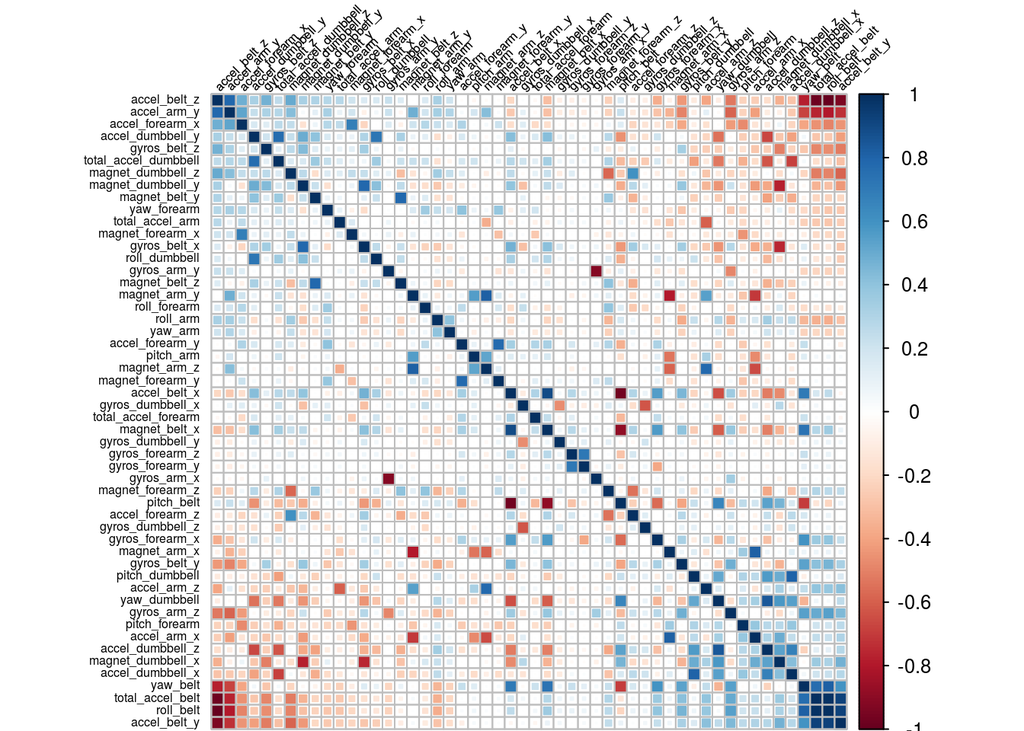

```r
corr_test <- cor(dftrain1[,-53])

library(corrplot)
corrplot(corr_test, method="square", order="FPC",
         tl.col="black", tl.srt=45, tl.cex=0.5)
```

The correlation plot above shows that there are indeed several features with a strong degree of correlation with others. For example, `roll_belt` is strongly correlated with `yaw_belt`, `total_accel_belt` and `accel_belt_y` (correlation larger than 0.75):

```r
corr_test[1,][corr_test[1,]>0.75]
```

```
##        roll_belt         yaw_belt total_accel_belt     accel_belt_y
##        1.0000000        0.8135025        0.9809184        0.9245978
```

When this happens a useful strategy is to preprocess the data with principal component analysis (PCA) to reduce the number of predictors, generating weighted combinations of features which capture the most information possible. Once the principal components are determined from the training subset, they are applied to the calibration set too.

```r
trainpca <- preProcess(dftrain1[,-53], method="pca")
dftrainpca <- predict(trainpca, dftrain1[,-53])
dfcalpca <- predict(trainpca, dfcal1[,-53])
```

I have selected the default threshold of 95 per cent for the cumulative percent of variance to be retained by the PCA. That choice yields 25 PCA components, a significant reduction in the number of features.

# Model construction

To construct my predictive model I have chosen the random forest method.

In order to avoid memory allocation errors in my machine, I had to restrict the size of my training sets to less than 7,000 observations. I also had to limit myself to building relatively small forests (250 trees) because larger forests take too long to compute.

```r
dftrainpca$classe <- dftrain1$classe
dfcalpca$classe <- dfcal1$classe

smallTrain <- createDataPartition(y=dftrainpca$classe, p=0.55, list=FALSE)
dftrain2 <- dftrainpca[smallTrain,]
my.model <- train(classe ~ ., data=dftrain2, method="rf", ntree=250,
                  trControl=trainControl(method="cv", number=4), prox=TRUE)
my.model$finalModel
```

```
##
## Call:
##  randomForest(x = x, y = y, ntree = 250, mtry = param$mtry, proximity = TRUE)
##                Type of random forest: classification
##                      Number of trees: 250
## No. of variables tried at each split: 2
##
##         OOB estimate of  error rate: 5.87%
## Confusion matrix:
##      A    B    C   D    E class.error
## A 1809   12    8   8    5  0.01791531
## B   43 1158   39   4   10  0.07655502
## C   15   35 1058  14    8  0.06371681
## D   16    4   78 957    7  0.09887006
## E    8   16   29  21 1117  0.06213266
```

By training the model with cross validation, I obtain an estimate for the out of box (OOB) error, 5.87% in this case. Even with the restrictions I had to impose due to my machine’s performance, I obtain a very accurate model (OOB at least).

# Model validation

I now apply the trained model on the calibration set, using the `predict` function. For consistency, I only use a partition of the calibration data (the same proportion I used to create the smaller training set), although this is probably not necessary. The output of the `confusionMatrix` function shows how well the model classified the calibration data, together with several accuracy measures.

```r
smallCal <- createDataPartition(y=dfcalpca$classe, p=0.55, list=FALSE)
dfcal2 <- dfcalpca[smallCal,]
confusionMatrix(dfcal2$class, predict(my.model, newdata=dfcal2))
```

```
## Confusion Matrix and Statistics
##
##           Reference
## Prediction    A    B    C    D    E
##          A 1201   17    6    2    2
##          B   29  774   21    7    4
##          C    9   25  711    7    1
##          D    8    2   43  645   10
##          E    2   27    9    8  748
##
## Overall Statistics
##
##                Accuracy : 0.9447
##                  95% CI : (0.9374, 0.9513)
##     No Information Rate : 0.2893
##     P-Value [Acc > NIR] : < 2.2e-16
##
##                   Kappa : 0.9299
##  Mcnemar's Test P-Value : 3.527e-09
##
## Statistics by Class:
##
##                      Class: A Class: B Class: C Class: D Class: E
## Sensitivity            0.9616   0.9160   0.9000   0.9641   0.9778
## Specificity            0.9912   0.9824   0.9881   0.9827   0.9871
## Pos Pred Value         0.9780   0.9269   0.9442   0.9110   0.9421
## Neg Pred Value         0.9845   0.9796   0.9778   0.9934   0.9952
## Prevalence             0.2893   0.1957   0.1830   0.1549   0.1772
## Detection Rate         0.2781   0.1792   0.1647   0.1494   0.1732
## Detection Prevalence   0.2844   0.1934   0.1744   0.1640   0.1839
## Balanced Accuracy      0.9764   0.9492   0.9440   0.9734   0.9824
```

The out of sample (OOS) error for this model is estimated from this as 1 minus the accuracy, so in this case I get that the OOS error for the model built is at least 5.53 per cent.

# Predicting on the test set

The final step is to download the test data and use the model on it to make predictions.

```r
if (!file.exists("data/pml-testing.csv")) {
  fileUrl <- "https://d396qusza40orc.cloudfront.net/predmachlearn/pml-testing.csv"
  download.file(fileUrl, destfile="data/pml-testing.csv", method="curl")
}

dftest <- read.table("data/pml-testing.csv", sep=",",
                     stringsAsFactors=FALSE, header=TRUE,
                      na.strings=c("","NA"))
dim(dftest)
```

```
## [1]  20 160
```

```r
dftest <- dftest[,c(features.list[-53],"problem_id")]
dftestpca <- predict(trainpca, dftest[,-53])
dftestpca$classe <- dftest$classe

final.prediction <- predict(my.model, newdata=dftestpca)
```

To complete the assignment I have to create individual text files for each prediction.

```r
pml_write_files <- function(x, outpath="./") {
  n <- length(x)
  for (i in 1:n) {
    filename <- paste0(outpath, "problem_id_", i, ".txt")
    write.table(x[i], file=filename, quote=FALSE, row.names=FALSE,
                col.names=FALSE)
  }
}

if (!file.exists("output")) { dir.create("output") }
pml_write_files(as.character(final.prediction), outpath="output/")
```

# Conclusion

In this project I created a model to predict the type of physical exercise based on accelerometer data. The final score obtained on the test data was 17 correct guesses out of 20 cases, 85 per cent accuracy. Here we see that the actual model error is larger than the estimated OOS error, but still much better than random guesses.

Random forest models are very accurate, but take a long time to train. In this case, because of the limited performance of my machine I had to restrict myself to train in a smaller sample and with a relatively small forest of only 250 trees. Nevertheless, the final results were very accurate; with more time and/or computing power, I am confident that the model accuracy can be increased.